# Assignment 1

Manuela Giansante

2023-03-02

```r
# Needed Packages
rm(list = ls())
library(dplyr)
library(fpp3)
library(ggplot2)
library(forecast)
library(tidyverse)
library(feasts)
```

### Exercise 3

```r
#Load the data
setwd("C:/Users/Manu/Desktop/master course/2nd semester/Forecasting/tps/week2")
traffic <- read.csv2("webtraffic.csv")
head(traffic)
```

```
##          Day Visitors  X
## 1 03.01.2022    10442 NA
## 2 04.01.2022    10514 NA
## 3 05.01.2022    10959 NA
## 4 06.01.2022    11020 NA
## 5 07.01.2022    11484 NA
## 6 08.01.2022     3641 NA
```

#### 1.Plot and analyse the data. Is there any seasonality? If yes, how it can be characterized? If no,why? Justify your answer

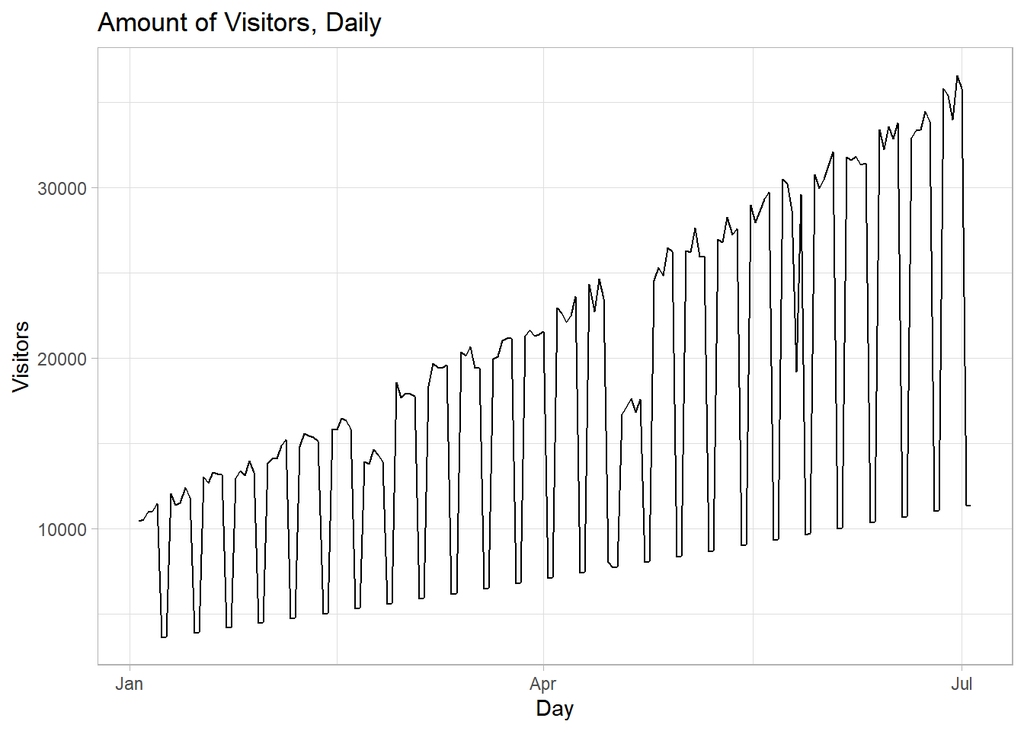

```r
traffic$Day<- as.Date(traffic$Day, format="%d.%m.%Y")#re-format the dates
traffic<-traffic[-3]   # get rid of the X column

traffic %>% ggplot(aes(Day, Visitors))+
  geom_line()+labs(title="Amount of Visitors, Daily")+
  theme_light()
```

```r
start_date <- as.Date("2022-03-01")
timeline <- seq(start_date, length.out = length(traffic$Visitors), by = "day")
```

The trend is increasing, the oscillation increases in width over time. This is due to the seasonal pattern the data follows, said pattern repeats itself over fixed periods of time. There are a couple of cases in which the peaks fail to maintain the increasing pattern behaviour, this does not seem to repeat itself after after a precise amount of time, could be attributable to a cycle.

```r
#Create tsibble object
traffic_tsb <- traffic %>%
  mutate(Timeline = timeline, .before = 1) %>%
  as_tsibble(index=Timeline)
```

#### 2. Make a time series decomposition applying additive and multiplicative models.

##### Additive Decomposition

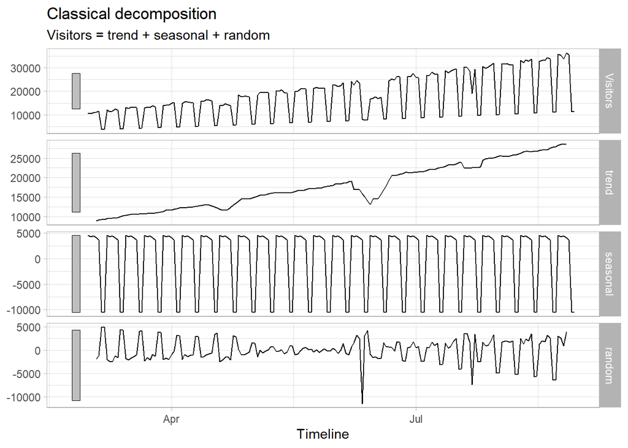

```r
# Plot the additive classical decomposition
traffic_tsb %>%
  model(classical_decomposition(Visitors, type = "additive"))%>% components()%>%autoplot()+theme_light()
```

We have computed the trend-cycle element $\hat{T_t}$, obtained the de-trended series: $y_t-\hat{T}_t=\hat{S}_t+\hat{R}_t$ . The seasonal component is the average of the de-trended series for each period. In order to check what kind of seasonality we are observing we use the `acf()` function.

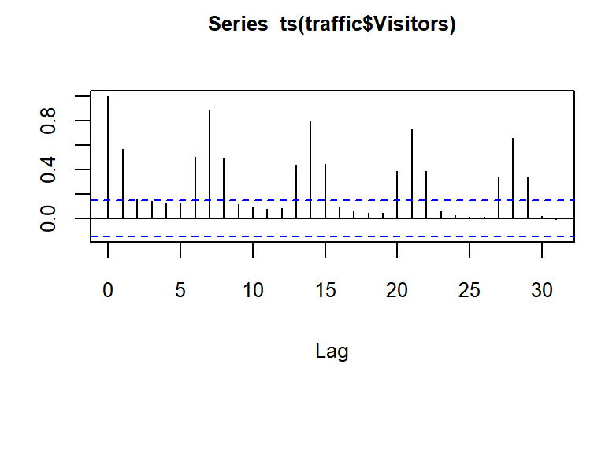

```r
# Plot the autocorrelation plot to check seasonality
par(mar=c(7, 3, 3, 1), cex.lab=0.8, cex.axis=0.8, cex.main=0.8)#graphics
acf(ts(traffic$Visitors), lag.max = 31)# autocorrelation plot
```

Present the autocorrelation function, which of course in the closest lags shows higher correlation. The spikes we observe are due to the seasonal component in the data which is why we plotted our the ACF function. We can see that the “seasonal” pattern is of weekly kind, because the higher spike is at lag 7. So the seasonal component computed by the `classical_decomposition`is weekly.

##### Multiplicative Decomposition

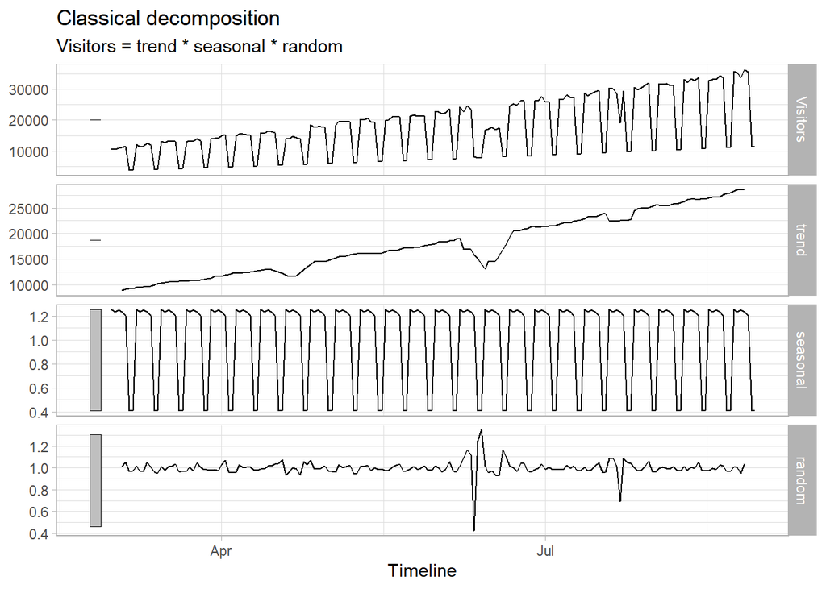

```r
# Plot the multiplicative decomposition
traffic_tsb %>%
  model(classical_decomposition(Visitors, type = "multiplicative"))%>% components()%>%autoplot()+theme_light()
```

In this case we have computed the de-trended series $y_t/\hat{T}_t=\hat{S}_t\times \hat{R}_t$. The seasonal component in this case changes in range because of how the elements interact with each other.

Between the two decompositions, the noise remainder elements that originates from the multiplicative contains less peaks than the one generated by the additive decomposition. Moreover, in the additive case the remainder does not look random at all, which would imply that there is autocorrelation in the data the selected process fails to model effectively.

#### 3.Repeat the decomposition using the STL approach.

##### STL Decomposition

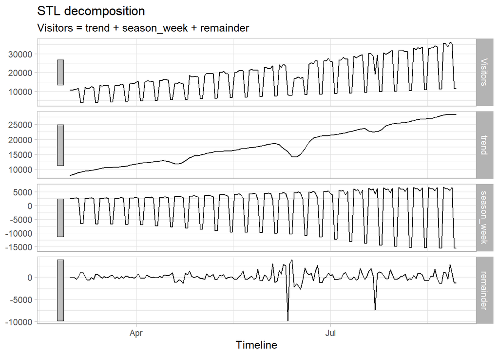

```r
# POLt the default STL decomposition
traffic_tsb %>% model(stl = STL(Visitors))%>% components()%>%autoplot()+theme_light()
```

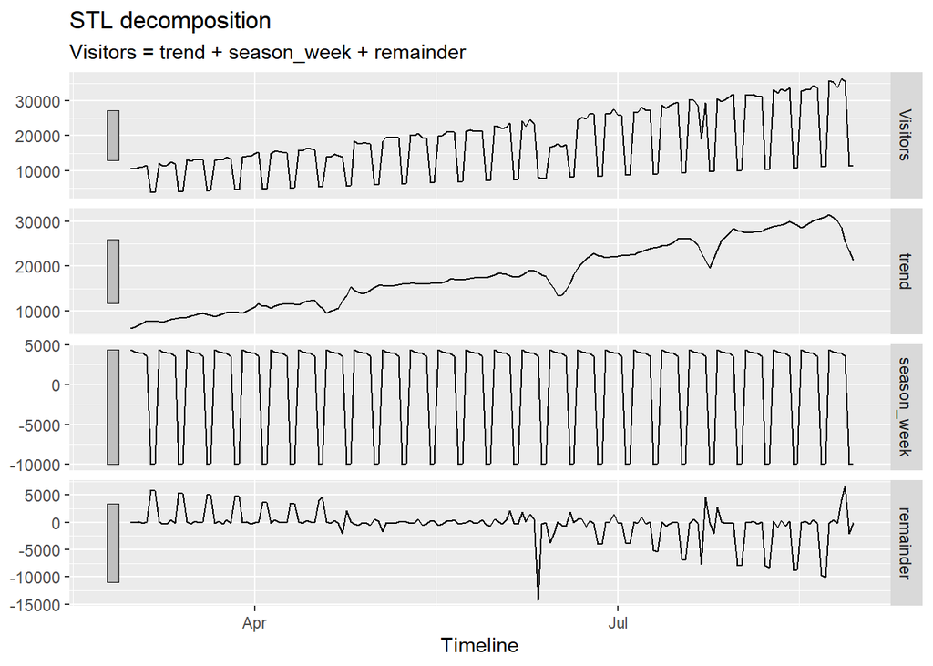

```r
# Plot the periodic STL decomposition
traffic_tsb %>%
model(STL(Visitors ~ trend(window = 7) + season(window = "periodic"), robust = TRUE)) %>%
components() %>%
autoplot()
```

We observe the two alternatives, the former case is the default case, so we are not assuming that the seasonality within the data is going to be constant in its variation in the long run. In fact, in the latter decomposition forcing such assumption by setting the window to periodic, results into a more “noisy” process. The remainder element is much less “busy” in the STL default case.

#### Which decomposition seems to be most relevant to the data?

Given that the seasonality variation grow in range as the trend increases, a multiplicative decomposition would be most appropriate. When considering the STL decomposition we have to consider the fact that in STL decomposition unless we coerce the seasonal component to “periodic” the seasonal component is not assumed to be constant over time. In fact, the seasonality might change in the future due to some weekly discount the website might implement or some content release day being moved. Yet, when simply comparing the STL default case and the multiplicative classical decomposition, the Rt that appears more random is the multiplicative one. Because of this a good idea, would be to log the data and then model the series once again.

#### 4.Extract trend component from each of three decompositions. Make a comparison by plotting it on the data plot. Do trends components differ? Why? Justify your answer.

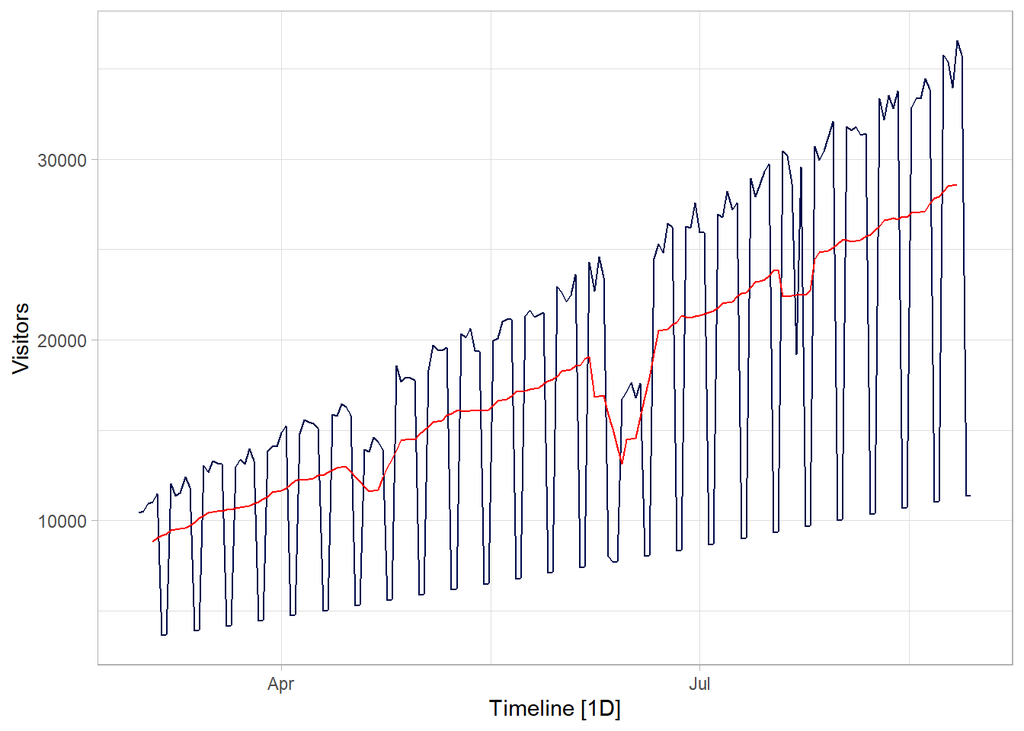

```r
# Plot the Additive trend-cycle
dcmp_add<- traffic_tsb %>% model(classical_decomposition(Visitors, type = "additive"))

components(dcmp_add)%>%
as_tsibble() %>%
autoplot(Visitors, colour="#000C4A") +
geom_line(aes(y=trend), colour = "red")+theme_light()
```

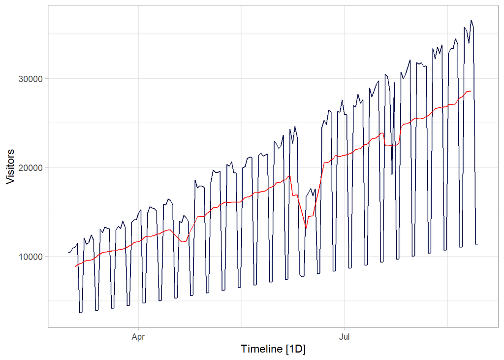

```r
# Plot the multiplicative trend-cycle
dcmp_mlt<- traffic_tsb %>% model(classical_decomposition(Visitors, type = "multiplicative"))

components(dcmp_mlt)%>%
as_tsibble() %>%
autoplot(Visitors, colour="#000C4A") +
geom_line(aes(y=trend), colour = "red")+theme_light()
```

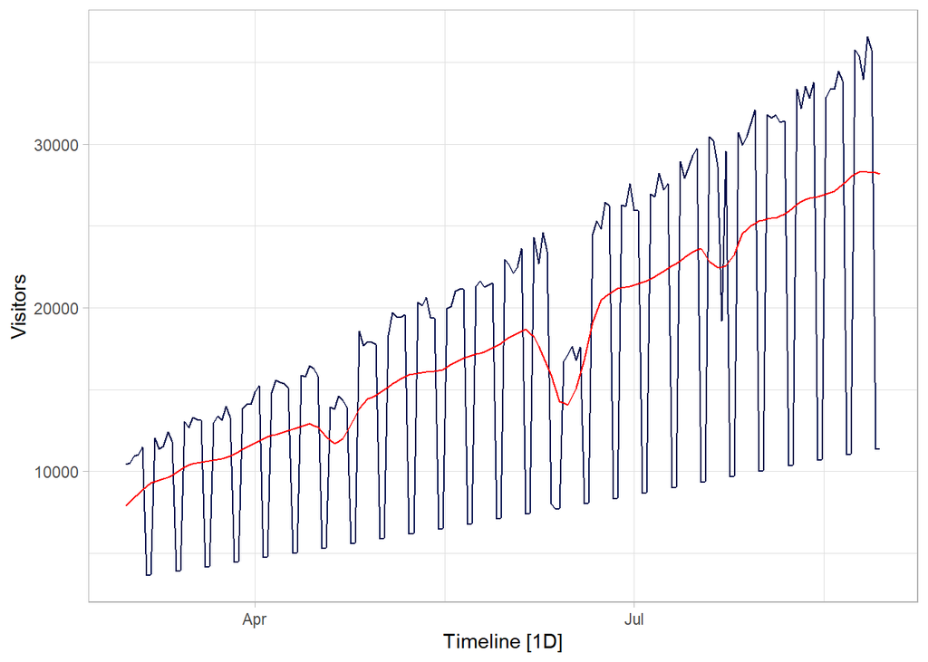

```r
# Plot the default STL trend-cycle
dcmp_stl<- traffic_tsb %>% model(stl = STL(Visitors))

components(dcmp_stl)%>%
as_tsibble() %>%
autoplot(Visitors, colour="#000C4A") +
geom_line(aes(y=trend), colour = "red")+theme_light()
```

#### 5.Extract seasonal component from each of three decompositions. Make a comparison. Do seasonal components differ? Provide a detailed comment on your findings.

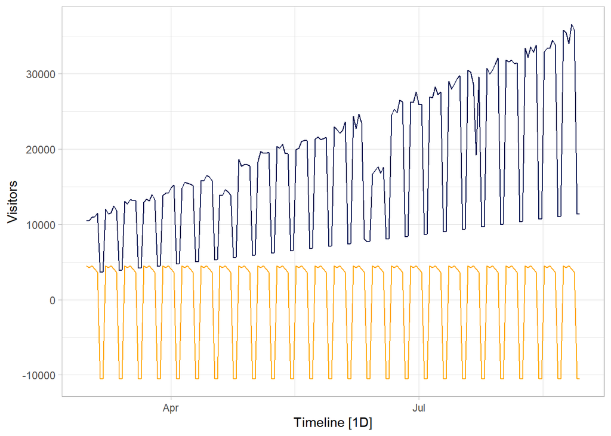

```r
# Plot the Additive seasonal component
components(dcmp_add)%>%
as_tsibble() %>%
autoplot(Visitors, colour="#000C4A") +
geom_line(aes(y=seasonal), colour = "orange")+theme_light()
```

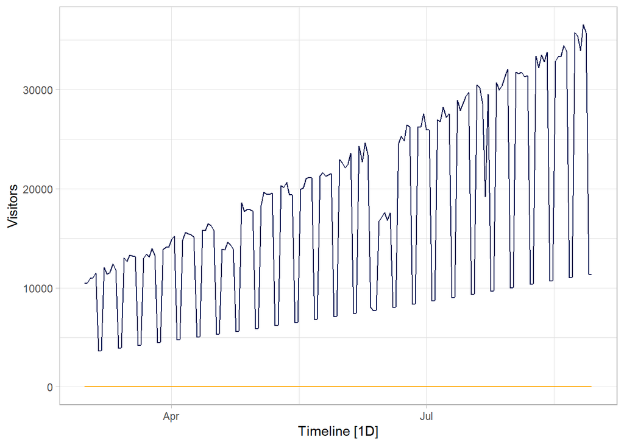

```r
# Plot the Multiplicative seasonal component
components(dcmp_mlt)%>%
as_tsibble() %>%
autoplot(Visitors, colour="#000C4A") +
geom_line(aes(y=seasonal), colour = "orange")+theme_light()
```

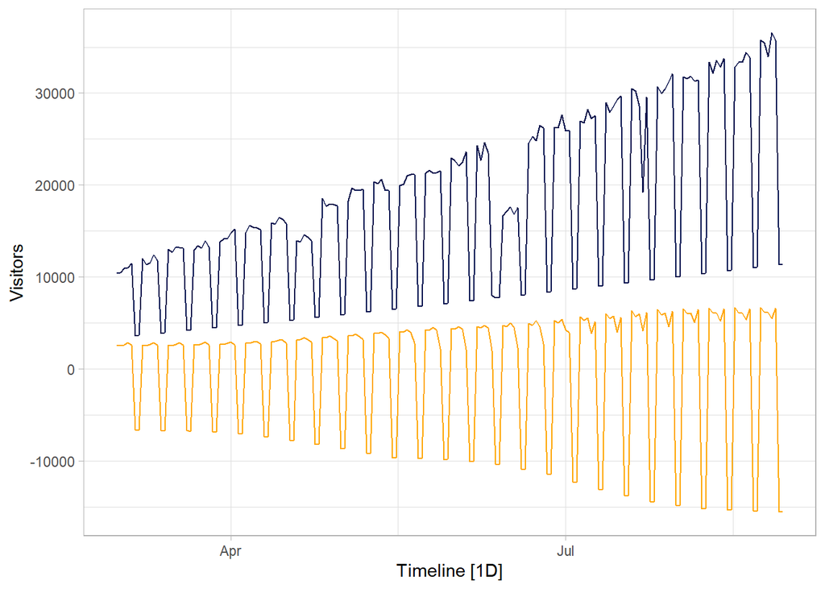

```r
# Plot the default STL seasonal component
components(dcmp_stl)%>%
as_tsibble() %>%
autoplot(Visitors, colour="#000C4A") +
geom_line(aes(y=season_week), colour = "orange")+theme_light()
```

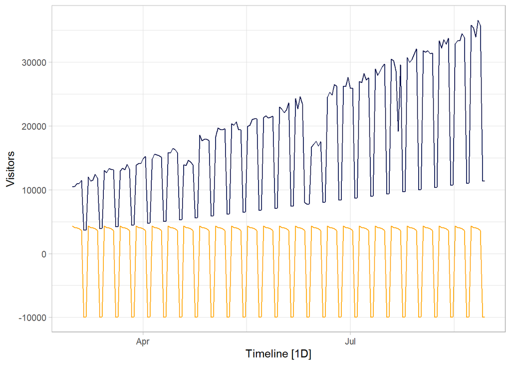

```r
dcmp_stl2<-traffic_tsb %>%
model(STL(Visitors ~ trend(window = 7) + season(window = "periodic"), robust = TRUE))

# Plot periodic STL decomposition
components(dcmp_stl2)%>%
as_tsibble() %>%
autoplot(Visitors, colour="#000C4A") +
geom_line(aes(y=season_week), colour = "orange")+theme_light()
```

### Exercise 4

- **What is the reason to apply a moving average to a moving average?**

  The use of a MA is the first step of classical decomposition, it allows us to estimate the trend-cycle at time t by taking the average of the series within k periods of t.

  A double MA is used in the case in which the data displays a even periodicity m, that is to make the MA symmetric. For example, is we were to compute the MA of a series with even periodicity, only once, our results would have asymmetric estimates (look at table3.2 of the book).

  By re-applying a MA to it we re-centre the estimates, this happens at $\hat{T}_{t+1/2}$.
- **Show that a 4x4 MA is a weighted moving average.**

  A 4x4MA is equivalent to a 7 weighted MA

  We estimate $\hat{T}_{t+1/2}=\frac{1}{2k}\sum^{k}_{j=-(k-1)}y_{t+j}$ which is an un-weighted moving average.

  Weighted moving average with even periodicity: $\hat{T}_{t+1/2}=\sum^{k}_{j=-(k-1)}a_jy_{t+j}$; we would assume symmetric weights so aj=a_-j and that they sum up to 1.

  Weighted moving averages result in a smoother trend-cycle.

  $\hat{T}_t=\frac{1}{4}(\frac{1}{4}\left(y_{t-3}+y_{t-2}+y_{t-1}+ y_{t}\right)+\\+\frac{1}{4}\left(y_{t-2}+y_{t-1}+y_t+y_{t+1}\right)+\\+\frac{1}{4}\left(y_{t-1}+y_t+y_{t+1}+y_{t+2}\right)+\\+\frac{1}{4}\left(y_t+ y_{t+1}+y_{t+1}+y_{t+3}\right))=\\=\frac{1}{16}y_{t-3}+\frac{2}{16}y_{t-2}+\frac{3}{16}y_{t-1}+\frac{4}{16}y_{t}+\frac{3}{16}y_{t+1}+\frac{2}{16}y_{t+2}+\frac{1}{16}y_{t+3}$

  $\hat{T_t}=\\=\frac{1}{7}(y_{t-3}+y_{t-2}+y_{t-1}+y_t+y_{t+1}+y_{t+2}+y_{t+3})]\\=\frac{1}{16}y_{t-3}+\frac{1}{4}y_{t-2}+\frac{1}{4}y_{t-1}+\frac{1}{4}y_{t}+\frac{1}{4}y_{t+1}+\frac{1}{4}y_{t+2}+\frac{1}{16}y_{t+3}$

  $\frac{1}{4}[\frac{1}{2k}\sum^{k}_{j=-(k-1)}y_{t+j}]=\sum^{k}_{j=-k}a_jy_{t+j}$
- **How many terms are involved? Compute the weights.**

  The MA is of order 4x4, which means that we average over 4 datapoint moving by 1 step and recomputing the average 4 different times, the terms involved are 7. We have computed the weights above, the last terms take weight 1/(4m).

  The weights have been computed above.
- **For what seasonality can it be applied?**

  Could be applied for data measured on a quarterly basis. Of course compared to a 2x4MA the resulting trend-cycle is smoother.
- **Provide two examples from the business world when 4x4 MA is appropriate.**

  Companies in the US have to file quarterly financial statements, so all those indices and figures will have to be re-centred when modelled for the generation of forecasts.

  (source: [Understanding a Quarterly Financial Report and Its Requirements (investopedia.com)](https://www.investopedia.com/ask/answers/122214/what-quarterly-report.asp) )

  Sales (which in fact are reported cumulatively into financial statements) can be grouped into quarterly groups. Because, of course for daily recorded data we can estimate quarterly statistics.

  ( source: [ADIDAS Quarterly Sales Forecasting | Kaggle](https://www.kaggle.com/code/kofi2614/adidas-quarterly-sales-forecasting) )